# homework08.md05

Author

Andrew Myerson

# HOMEWORK #8 MD 5

```r
#/ message: false

library(tidyverse)
twitch_data <- read_csv('twitchdata-update.csv')
```

```r
library(janitor)
twitch_data <- clean_names(twitch_data)

# Inspect new names
colnames(twitch_data)
```

```
 [1] "channel"             "watch_time_minutes"  "stream_time_minutes"
 [4] "peak_viewers"        "average_viewers"     "followers"
 [7] "followers_gained"    "views_gained"        "partnered"
[10] "mature"              "language"
```

## Question 1

```r
sample5 <- twitch_data |>
  sample_n(size = 5) |>
  select(channel, average_viewers, followers)

sample5
```

```
# A tibble: 5 × 3
  channel          average_viewers followers
  <chr>                      <dbl>     <dbl>
1 Peereira7                   1377    377689
2 SparkofPhoenixTV            1462    433078
3 룩삼 (looksam)              3302    285474
4 jean_mago                   2012    342691
5 Elwind                      7165    703464
```

```r
q1 <- twitch_data |>
  select(channel, average_viewers, followers)

summary(q1)
```

```
   channel          average_viewers    followers
 Length:1000        Min.   :   235   Min.   :   3660
 Class :character   1st Qu.:  1458   1st Qu.: 170546
 Mode  :character   Median :  2425   Median : 318063
                    Mean   :  4781   Mean   : 570054
                    3rd Qu.:  4786   3rd Qu.: 624332
                    Max.   :147643   Max.   :8938903
```

The mean average viewers is 4781 while the maximum is 147,643, which is very high. This captures my attention because this might be a sign that there are many high outliers or the distribution is heavily skewed to the right, especially since the mean is higher than the median. The mean is also higher than the median for followers and similarly has a very high maximum of 8,938,903.

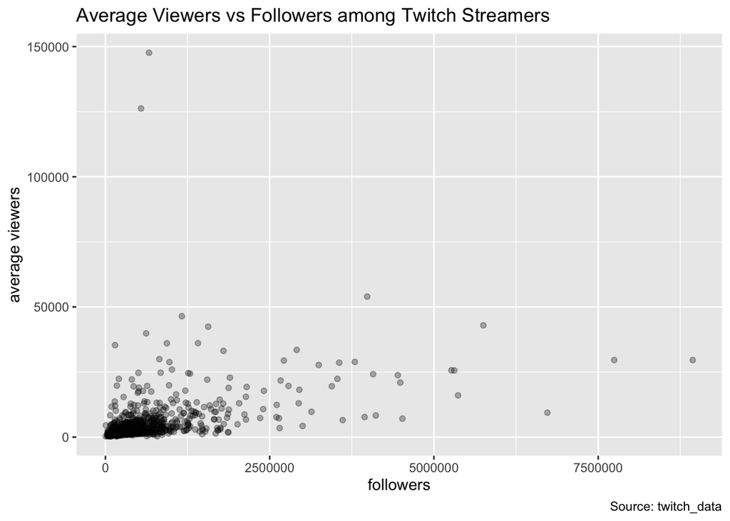

```r
ggplot(twitch_data,
       mapping = aes(x = followers,
                     y = average_viewers)) +
  geom_jitter(alpha = 0.3) +
  labs(title = "Average Viewers vs Followers among Twitch Streamers", caption = "Source: twitch_data", x = "followers", y = "average viewers")
```

I notice a scatterplot with almost all of the points scattered around the origin with very low followers and average viewers. Most outliers are streamers with lots of followers but a similar amount of average viewers, with 2 high outliers who have a high amount of average viewers but few followers, who may have gone viral.

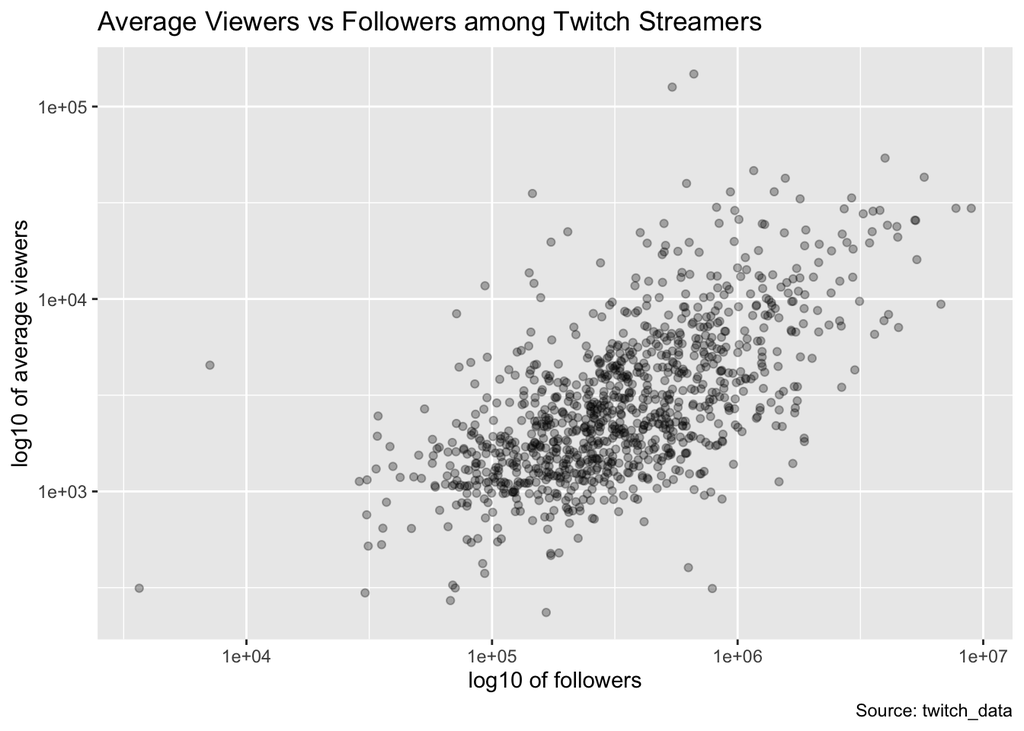

```r
ggplot(twitch_data,
       mapping = aes(x = followers,
                     y = average_viewers)) +
  geom_jitter(alpha = 0.3) +
  labs(title = "Average Viewers vs Followers among Twitch Streamers", caption = "Source: twitch_data", x = "log10 of followers", y = "log10 of average viewers") +
  scale_x_log10() +
  scale_y_log10()
```

Now after adding scale_x_log10() and scale_y_log10() to the code for the graph, I can more clearly see the relationship between followers and average viewers because the data isn’t all scattered in one area on the Cartesian plane. I can see a moderately strong position linear relationship between followers and average viewers, as shown by the upward trend in points.

```r
twitch_data <- twitch_data %>%
  mutate(log_viewers = log10(average_viewers),
         log_followers = log10(followers))
```

## Question 2

```r
fit1 <- lm(log_viewers ~ log_followers,
           data = twitch_data)

broom::tidy(fit1)
```

```
# A tibble: 2 × 5
  term          estimate std.error statistic   p.value
  <chr>            <dbl>     <dbl>     <dbl>     <dbl>
1 (Intercept)      0.198    0.125       1.58 1.15e-  1
2 log_followers    0.588    0.0226     26.0  1.69e-114
```

```r
fit1
```

```
Call:
lm(formula = log_viewers ~ log_followers, data = twitch_data)

Coefficients:
  (Intercept)  log_followers
       0.1978         0.5885
```

```r
#/ followers is the independent variable and viewers is the dependent variable!
```

$$1.1^{0.59} = 1.0578 $$

After running the linear model to examine the relationship between log_followers and log_viewers, I can see that whenever there is a 10% increase in followers, there is an expected increase of 5.78% increase in average viewers.

## Question 3

```r
library(broom)

pred_data <- augment(fit1)

# glimpse our new data
glimpse(pred_data)
```

```
Rows: 1,000
Columns: 8
$ log_viewers   <dbl> 4.442731, 4.408410, 4.040444, 3.887280, 4.471321, 4.6275…
$ log_followers <dbl> 6.511388, 6.725108, 6.247393, 6.596030, 6.951284, 6.1940…
$ .fitted       <dbl> 4.029761, 4.155534, 3.874400, 4.079572, 4.288638, 3.8430…
$ .resid        <dbl> 0.4129697, 0.2528757, 0.1660436, -0.1922928, 0.1826833, …
$ .hat          <dbl> 0.006194481, 0.008694557, 0.003782169, 0.007126066, 0.01…
$ .sigma        <dbl> 0.3085580, 0.3087321, 0.3087919, 0.3087764, 0.3087820, 0…
$ .cooksd       <dbl> 0.0056128779, 0.0029688873, 0.0005513456, 0.0014026033, …
$ .std.resid    <dbl> 1.3420109, 0.8227954, 0.5389316, -0.6251793, 0.5953620, …
```

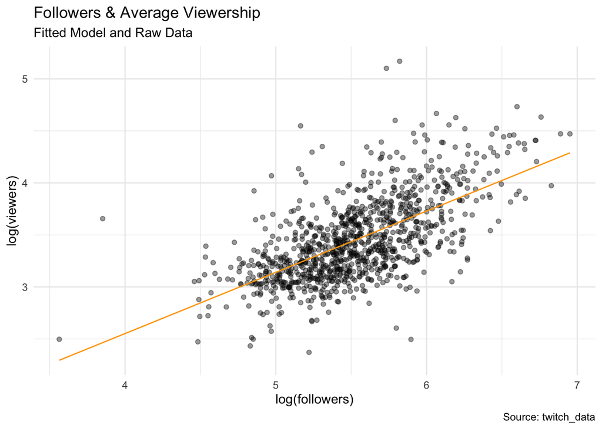

```r
pred_data %>%
  ggplot(aes(x = log_followers,
             y = log_viewers)) +
  geom_jitter(alpha = 0.4) +
  geom_line(aes(x = log_followers,
                y = .fitted),
            col = "orange") +
  theme_minimal() +
  labs(subtitle = "Fitted Model and Raw Data",
       title = "Followers & Average Viewership",
       x = "log(followers)",
       y = "log(viewers)",
       caption = "Source: twitch_data")
```

Yes, I do think that our linear model predicts the relationship between followers and average viewers very well because it follows the upward trend of the points in the scatterplot and captures the overall pattern.

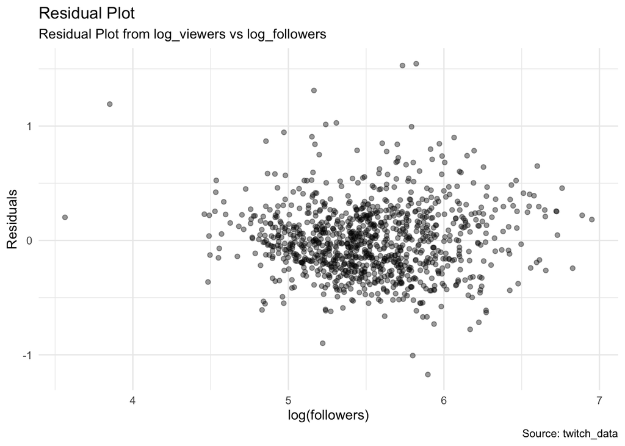

```r
pred_data |>
  ggplot(aes(x = log_followers,
             y = .resid)) +
  geom_jitter(alpha = 0.4) +
  theme_minimal() +
  labs(subtitle = "Residual Plot from log_viewers vs log_followers",
       title = "Residual Plot",
       x = "log(followers)",
       y = "Residuals",
       caption = "Source: twitch_data")
```

I see a residual plot that shows the distance from each point to the linear model that was shown on the previous graph. As expected because our linear model is a good fit, most residuals center around 0 because there is little difference on average between each point and the line. However, there are a few big outliers with a residual over 1.5 or below -1. However these big residuals do not happen often in a particular range of log_followers so the linear model is a solid fit for this data and predicts the average viewers (log_viewers) well for the entire range of our x-variable (log_followers).

## Question 4

```r
lingua <- twitch_data |>
  select(channel, language, average_viewers)

lingua
```

```
# A tibble: 1,000 × 3
   channel    language   average_viewers
   <chr>      <chr>                <dbl>
 1 xQcOW      English              27716
 2 summit1g   English              25610
 3 Gaules     Portuguese           10976
 4 ESL_CSGO   English               7714
 5 Tfue       English              29602
 6 Asmongold  English              42414
 7 NICKMERCS  English              24181
 8 Fextralife English              18985
 9 loltyler1  English              22381
10 Anomaly    English              12377
# ℹ 990 more rows
```

```r
lingua |>
  sample_n(size = 10)
```

```
# A tibble: 10 × 3
   channel            language   average_viewers
   <chr>              <chr>                <dbl>
 1 pqueen             Turkish               2602
 2 ipav999            English                737
 3 CaMaK              French                1759
 4 LuquEt4            Portuguese            1081
 5 ElmiilloR          Spanish               5163
 6 햇살살 (hatsalsal) Korean                1302
 7 UCCleague          Russian               1378
 8 Shlorox            German                5216
 9 Myth               English               9396
10 VooDooSh           Russian               2519
```

```r
summary(lingua)
```

```
   channel            language         average_viewers
 Length:1000        Length:1000        Min.   :   235
 Class :character   Class :character   1st Qu.:  1458
 Mode  :character   Mode  :character   Median :  2425
                                       Mean   :  4781
                                       3rd Qu.:  4786
                                       Max.   :147643
```

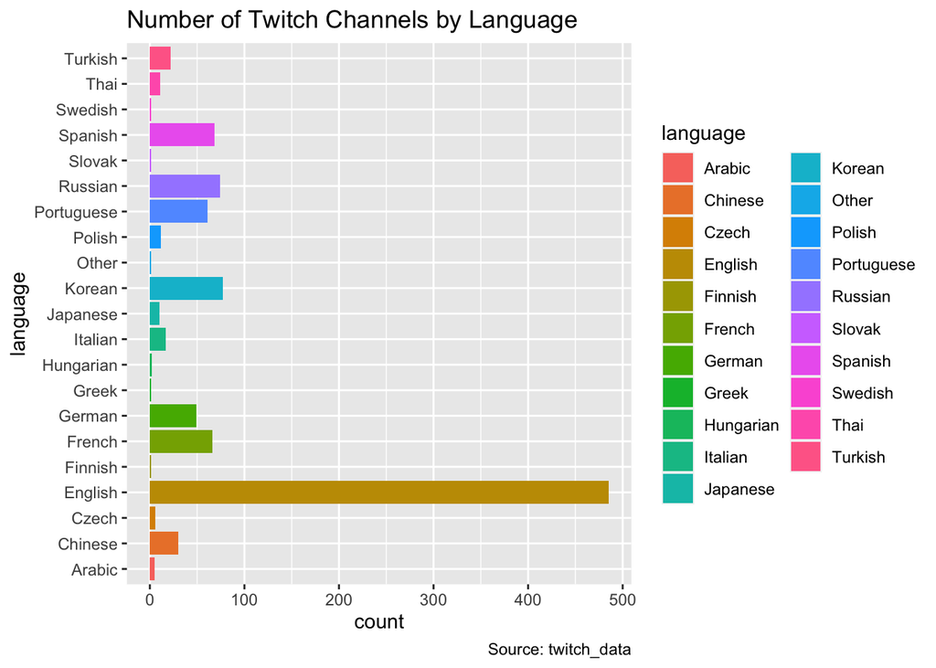

```r
ggplot(lingua,
       mapping = aes(x = language,
                     fill = language)) +
  geom_bar() +
  coord_flip() +
  labs(title = "Number of Twitch Channels by Language", caption = "Source: twitch_data")
```

I used summary() to summarize the quantitative variable, average viewers. However, it doesn’t make sense to summarize the data by using summary() for the categorical variable, language, so I made the bar graph above instead. The distribution of average viewers is skewed to the right (as shown by the histogram below) with a mean of 4781 and a very high maximum average viewership of 147,643, which is the channel called “dota2ti”. The distribution of languages in the data set of twitch channels includes 20 different languages and an additional bin called “other”. English is the most popular language with over 450 channels, followed by Korean, Russian, and Spanish.

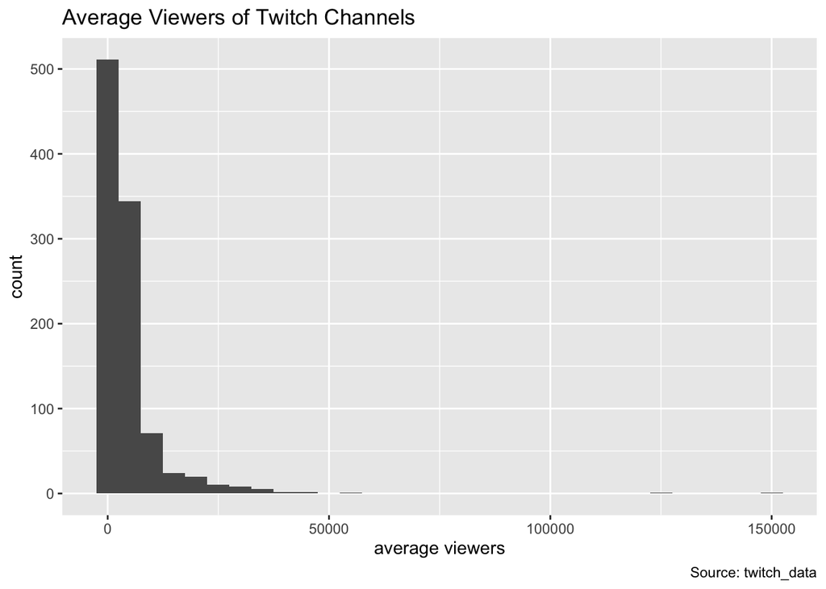

```r
ggplot(lingua,
       aes(x = average_viewers)) +
  geom_histogram(binwidth = 5000) +
  labs(title = "Average Viewers of Twitch Channels", x = "average viewers", caption = "Source: twitch_data")
```

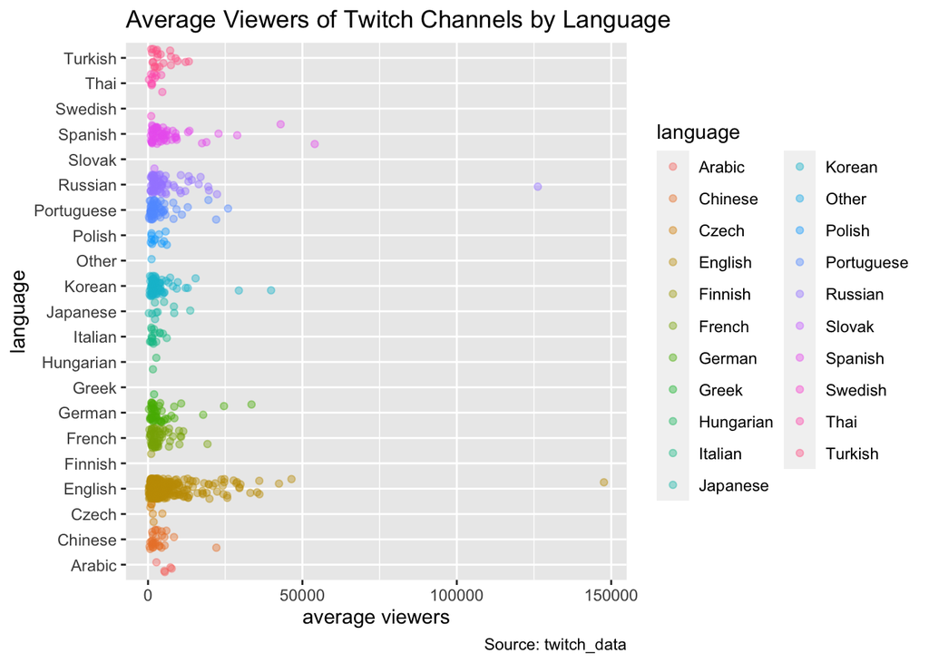

```r
ggplot(lingua,
       mapping = aes(x = language,
                     y = average_viewers,
                     color = language)) +
  geom_jitter(alpha = 0.4) +
  coord_flip() +
  labs(title = "Average Viewers of Twitch Channels by Language", x = "language", y = "average viewers", caption = "Source: twitch_data")
```

I plotted the 2 variables on the graph above. Here I can compare the distributions of average viewers for each language. As expected, English has the most channels and therefore has the widest range of average viewers among those channels. The channels for most languages have an average viewership from 235 (the lowest) to 12500. Something that stands out to me is that Russian has one very high outlier with over 125000 average viewerss, more viewers than every English channel except for one that has nearly 150000 average viewers. However, after digging deeper, I realized that these are actually the same channel but in different languages: dota2ti in English and dota2ti_ru in Russian.

## Question 5

```r
fit2 <- lm(average_viewers ~ language,
           data = lingua)

broom::tidy(fit2)
```

```
# A tibble: 21 × 5
   term              estimate std.error statistic p.value
   <chr>                <dbl>     <dbl>     <dbl>   <dbl>
 1 (Intercept)          5682.     3788.     1.50    0.134
 2 languageChinese     -2257.     4092.    -0.552   0.581
 3 languageCzech       -3855.     5129.    -0.751   0.453
 4 languageEnglish      -569.     3808.    -0.150   0.881
 5 languageFinnish     -4655.     9279.    -0.502   0.616
 6 languageFrench      -2176.     3929.    -0.554   0.580
 7 languageGerman      -1404.     3977.    -0.353   0.724
 8 languageGreek       -3721.     9279.    -0.401   0.688
 9 languageHungarian   -3542.     7087.    -0.500   0.617
10 languageItalian     -3477.     4310.    -0.807   0.420
# ℹ 11 more rows
```

```r
fit2
```

```
Call:
lm(formula = average_viewers ~ language, data = lingua)

Coefficients:
       (Intercept)     languageChinese       languageCzech     languageEnglish
            5682.2             -2257.4             -3854.5              -569.4
   languageFinnish      languageFrench      languageGerman       languageGreek
           -4655.2             -2175.7             -1404.0             -3721.2
 languageHungarian     languageItalian    languageJapanese      languageKorean
           -3541.7             -3476.7              -919.6             -1768.3
     languageOther      languagePolish  languagePortuguese     languageRussian
           -4533.2             -2776.9             -1881.3               912.0
    languageSlovak     languageSpanish     languageSwedish        languageThai
           -3610.2               767.5             -4655.2             -3670.8
   languageTurkish
            -921.3
```

```r
#/ get_regression_table(fit2) wouldn't work...

#/ followers is the independent variable and viewers is the dependent variable!
```

```r
lingua <- twitch_data %>%
  mutate(language = as.factor(language),
         language = relevel(language, ref = "English"))
```

```r
twitch_data |>
  summarize(standard_deviation = sd(average_viewers, na.rm = TRUE))
```

```
# A tibble: 1 × 1
  standard_deviation
               <dbl>
1              8454.
```

## Question 6

```r
library(broom)

q6 <- augment(fit2)

# glimpse our new data
glimpse(q6)
```

```
Rows: 1,000
Columns: 8
$ average_viewers <dbl> 27716, 25610, 10976, 7714, 29602, 42414, 24181, 18985,…
$ language        <chr> "English", "English", "Portuguese", "English", "Englis…
$ .fitted         <dbl> 5112.814, 5112.814, 3800.934, 5112.814, 5112.814, 5112…
$ .resid          <dbl> 22603.186, 20497.186, 7175.066, 2601.186, 24489.186, 3…
$ .hat            <dbl> 0.002061856, 0.002061856, 0.016393443, 0.002061856, 0.…
$ .sigma          <dbl> 8444.313, 8449.818, 8472.094, 8474.843, 8438.923, 8390…
$ .cooksd         <dbl> 7.019555e-04, 5.772431e-04, 5.788931e-04, 9.296361e-06…
$ .std.resid      <dbl> 2.6710814, 2.4222095, 0.8540523, 0.3073893, 2.8939553,…
```

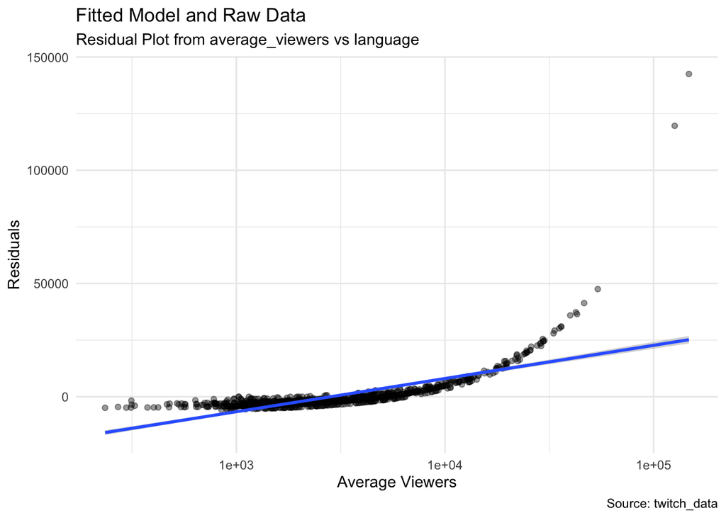

```r
ggplot(q6,
       aes(x = average_viewers,
           y = .resid)) +
  geom_jitter(alpha = 0.4) +
  geom_smooth(method = lm) +
  theme_minimal() +
  labs(subtitle = "Residual Plot from average_viewers vs language",
       title = "Fitted Model and Raw Data",
       x = "Average Viewers",
       y = "Residuals",
       caption = "Source: twitch_data") +
  scale_x_log10()
```

The 2 points that our model really missed are the 2 points on the above residual plot that have very high residuals: dota2ti in English with a residual of 142530.186, and dota2ti_ru in Russian with a residual of 119637.770.